# Untitled

Justin Herman

8/26/2019

# Looking into FEC Individual level fundraising for Democratic Party

The FEC requires candidates file their contributions for the 2020 elections with the agency. The data is uploaded as forms which the FEC cleans and adds to CSV files. The data is a treasure-trove of information. Polls get attention from week to week, but the news generally lacks any deep analysis of the FEC filings. Reporting typically covers headline numbers advertising total volume of donations and total amount. The FEC data is rich with self-identifying donor information. People identify their position, industry and location. Money acts as a proxy for electoral success. In the 2020 primary almost all candidates have sworn off contributions from lobbyists. On the surface, this is a noble attempt by democratic candidates to prove they aren’t influenced by corporations. However, digging below the surface, there is plenty of corporate influence in the FEC data.

**Data integrity concerns**

The FEC mandates quarterly reports to track the individual contributions into democratic candidate’s accounts. As a disclaimer It seems the engineers on the FEC website are slowly going through the individual files on the candidates and adding them to the Big table located on FEC pages [here](https://www.fec.gov/data/receipts/individual-contributions/?two_year_transaction_period=2020&min_date=01%2F01%2F2019&max_date=12%2F31%2F2019). Originally, I pulled the data from the above link, but the raw data is available on the website in full and some of the candidates q2 FEC filings hadn’t been added to the above database. Therefore, for this report I just grabbed all the individual level csv files and did my own manipulation on the data. It seems I keep several individual level contributors’ (less than .1%) for each candidate that were discarded for whatever reason by the FEC data engineers. The FEC filings aren’t representative of the whole population of donors, as reporting under 200 $ isn’t mandatory. We know that all these candidates have reached 100k contributors, yet most candidates in the database have less than 100k donations listed.

Some other peripheral information, caps are given on individual level contributions at 2800 per year. Throughout the FEC report there are some people who exceed these limits, they are known as conduits. Conduits are individuals that act on behalf of other people to give a donation to a candidate. These conduits aren’t restricted by the $ 2800 level if they exercise no discretion over where the funds go.

**Assumptions**

Below I make several categorizing assumptions in my data manipulation operations. The regex approach I took to clustering these groups will absolutely include some examples that do not actually represent the categorization of job title that I have made. RegEX is a brute force attempt to categorize the occupations algorithmically. However, as I have tracked the original job occupation, you can see overwhelmingly that these job titles are correctly identified. I display tables for each new clustered position, so that the reader understands that the approach is largely effective. My aggregated DF is at my website, I have categorized all job titles that have been changed with a binomial field to track them. Please feel free to look at the assumptions I made and the false captures in the clusters. if you would like to take this on in your own analysis, or perhaps develop your own clusters, please feel free to do so as well. The original unedited job titles are still present in the dataset.

**The Plan**

There are many different combinations of the same job title, my solution is to create new clustered occupation columns, which tracks and categorize occupations based upon corporate structures of power. I.E looking at the FEC data you would find examples of the words “C.E.O” “Chief executive officer” “chief officer” “Chief executive”. I bundle all these roles into a singular role of CEO. Other Self-reporting words like “Founder”, “EXECUTIVE DIRECTOR”, and “President” are also representative of those in charge of their organization, so they are also labeled as C.E.O. From there I step down the corporate ladder and attempt to identify all general C level executives as c level executives and place the rest of executive positions into a category of eXECS.

## Job Clustering

```
## [1] 3273
```

| different_names | counts |
| --- | --- |
| CEO | 2688 |
| President & CEO | 152 |
| Founder & CEO | 49 |
| CEO/Founder | 35 |
| Chairman & CEO | 34 |
| President And CEO | 26 |
| Environmental CEO/Author | 20 |
| President/CEO | 17 |
| Co-CEO | 14 |
| Nonprofit CEO | 11 |
| Pres/CEO | 10 |
| Founder and CEO | 9 |
| NON PROFIT CEO | 8 |
| CEO/Engineer | 7 |
| Founder/CEO | 7 |
| PRS/CEO | 7 |
| CEO & Founder | 6 |
| CFO/CEO | 6 |
| Founder And CEO | 6 |
| Physicist/CEO | 6 |

**CEO**

```
## [1] 7522
```

| Different_CEO_Titles | Count |
| --- | --- |
| CEO | 2902 |
| PRESIDENT | 1812 |
| EXECUTIVE DIRECTOR | 847 |
| FOUNDER | 367 |
| MANAGING PARTNER | 224 |
| CHIEF EXECUTIVE OFFICER | 194 |
| PRESIDENT & CEO | 157 |
| CO-FOUNDER | 105 |
| FOUNDER & CEO | 52 |
| CEO/FOUNDER | 35 |
| CHAIRMAN & CEO | 34 |
| PRESIDENT AND CEO | 28 |
| ENVIRONMENTAL CEO/AUTHOR | 20 |
| EXEC DIRECTOR | 19 |
| PRESIDENT AND ARTIST | 18 |
| FOUNDER AND CEO | 17 |
| PRESIDENT/CEO | 17 |
| FOUNDER & PRESIDENT | 16 |
| CO-CEO | 15 |
| NON-PROFIT EXEC. DIRECTOR | 15 |
| NON PROFIT CEO | 14 |
| EXEC. DIR. | 11 |
| FOUNDER/CEO | 11 |
| INTERIM EXECUTIVE DIRECTOR | 11 |
| NONPROFIT CEO | 11 |

**Executives**

We have increased our EXECUTIVE captures from 2570 to 8552

```
## [1] 8552
```

| Different_ExECUTIVE_Titles | Count |
| --- | --- |
| EXECUTIVE | 2570 |
| DIRECTOR | 1671 |
| PARTNER | 565 |
| DIRECTOR OF OPERATIONS | 152 |
| ACCOUNT EXECUTIVE | 130 |
| DIRECTOR OF SALES & MARKETING | 72 |
| BUSINESS EXECUTIVE | 71 |
| DIRECTOR AT AMCEA | 69 |
| EXECUTIVE COACH | 59 |
| BOARD MEMBER | 56 |
| NONPROFIT EXECUTIVE | 53 |
| EXECUTIVE PRODUCER | 51 |
| IT EXECUTIVE | 48 |
| MARKETING EXECUTIVE | 47 |
| DIRECTOR OF IT | 45 |

**C-Level_Execs**

The last high level clustering I performed was C-level executives. Arguably some of these positions could have been identified in the CEO cluster(Managing Director). Overall 3680 people are now identified as C level Execs

*Top 3027 uses of C-level executive title with original unedited job title.**

| Different_C_level_Titles | Count |
| --- | --- |
| FINANCIAL DIRECTOR | 844 |
| CFO | 436 |
| MANAGING DIRECTOR | 322 |
| COO | 297 |
| CTO | 263 |
| CHAIRMAN | 226 |
| SVP | 100 |
| CHIEF FINANCIAL OFFICER | 75 |
| EXECUTIVE VICE PRESIDENT | 57 |
| CHIEF OPERATING OFFICER | 38 |
| EVP | 36 |
| CIO | 35 |
| VICE CHAIRMAN | 35 |
| CMO | 33 |
| EXECUTIVE VP | 30 |
| CBO | 29 |
| CORPORATE EXECUTIVE | 29 |
| CHIEF MARKETING OFFICER | 24 |
| EXECUTIVE / COO | 19 |
| SENIOR MANAGING DIRECTOR | 19 |
| EXECUTIVE CHAIRMAN | 17 |
| CHAIRMAN OF THE BOARD | 16 |
| CHIEF CREATIVE OFFICER | 16 |
| CHIEF MEDICAL OFFICER | 16 |
| CHIEF INFORMATION OFFICER | 15 |

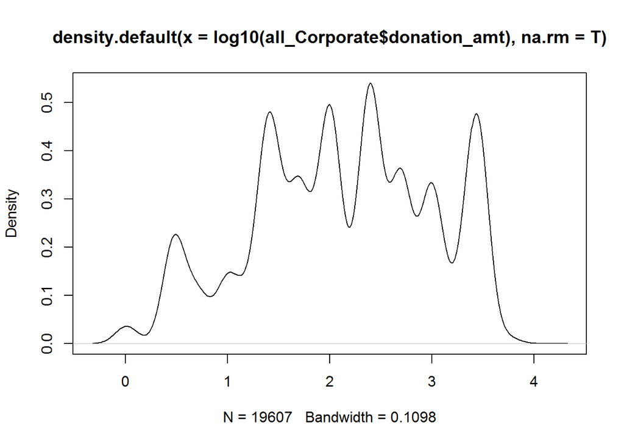

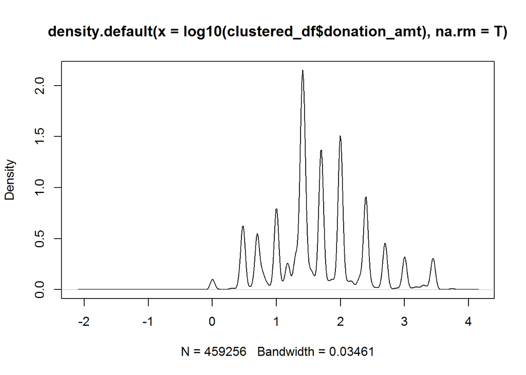

[figure not shown]

```
##                            vars      n   mean      sd median trimmed
## Original Data CEO Only        1   2902 710.09 1061.44 250.00  532.22
## Clustered Data CEO Only       1   7522 705.51 1044.44 250.00  531.90
## Full Dataset All Positions    1 460129 201.39  539.03  38.29   74.29
##                               mad   min   max range skew kurtosis    se
## Original Data CEO Only     333.58 -2800  5600  8400 1.45     2.65 19.70
## Clustered Data CEO Only    341.00 -2800  5600  8400 1.40     1.94 12.04
## Full Dataset All Positions  46.39 -7200 11200 18400 4.28    24.96  0.79
```

## Animations

[figure not shown]

[figure not shown]

## Clustering code (Only Coders)

- Feel free to skip this section if you don’t code in R

```r
## Function changes occupation based upon a regular expression.
## Creates column to note if change was made,stores old names, returns DF
cluster_jobs <- function(df,reg_express,replacement_val){

    ## Populate new col with imputed value
    df$clustered_jobs[str_detect(df$clustered_jobs,reg_express)] <- replacement_val
    ## Build column to track if change was made to occupation
    df <- df %>%
            mutate(job_changed = ifelse(clustered_jobs == job_position,'0','1'))
    return(df)
}

 ## Build new_jobs_col
final_df <- final_df %>%
  mutate(job_position= toupper(job_position))  %>%
  mutate(clustered_jobs = job_position)

## create Date column

## Job Clustering
clustered_df <- cluster_jobs(final_df,"CEO","CEO")
clustered_df$clustered_jobs <- as.character(clustered_df$clustered_jobs)
clustered_df$clustered_jobs[is.na(clustered_df$clustered_jobs)] <- "Not selected"

## GRAB SOME EXLCUSIONS
clustered_df <- cluster_jobs(clustered_df,"EXECUTIVE RECRUITER|EXECUTIVE SEARCH|RECRUITER","rECRUITER")


## Executive level positions
## WORDS INTENTIONALLY ARE REPLACED WITH SOME LOWERCASE LETTERS

clustered_df <- cluster_jobs(clustered_df,'EXECUTIVE ASSISTANT|EXEC. A|EXECUTIVE ASSITANT|EXEC ASST|EXECUTIVE ADMINISTRATOR|EXECUTIVE COORDINATOR|EXECUTIVEASSISTANT','EX aSSISTANT')
clustered_df <- cluster_jobs(clustered_df,"CHIEF EXECUTIVE OFFICER|MANAGING PARTNER|EXECUTIVE DIRECTOR|^PRESIDENT\\b|^FOUNDER\\b|EXEC.*DIR","CEO")
#clustered_df <- cluster_jobs(clustered_df,'^PRESIDENT\\b|^FOUNDER\\b|EXEC.*DIR',"CEO")
clustered_df <- cluster_jobs(clustered_df,'CHIEF \\w* OFFICER|^C[A-D|F-Z]O\\b|/C[A-D|F-Z]O\\b|^EXECUTIVE OFFICER',"ClEVEL_eXECS")
clustered_df <- cluster_jobs(clustered_df,'EXECUTIVE VICE PRESIDENT|FINANCIAL DIRECTOR|CORPORATE EXECUTIVE|SVP|EXECUTIVE VP|EVP|MANAGING DIRECTOR|CHAIRMAN|CORPORATE OFFICER|COO$','ClEVEL_eXECS')
clustered_df <- cluster_jobs(clustered_df,'^EXECUTIVE$|EXEC|EXECUTIVE$|^PARTNER|^DIRECTOR|MANAGING|CHAIR OF| CHAIR|BOARD |CO-C',"eXECS")
clustered_df <- cluster_jobs(clustered_df,'^VP|VP\\b|VICE PRESIDENT','Vp roles')


## RANDOM EXCLUSIONS
clustered_df <- cluster_jobs(clustered_df,"CHRISTIAN|^MINISTER|RABBI|PRIEST|CHAPLAIN|PARISH|CLERGY|BISHOP|PASTOR",'rELIOGOUS')

## LEGAL
clustered_df <- cluster_jobs(clustered_df,'LAWYER|ATTORNEY|GENERAL COUNSEL|COUNSEL$|PROSECUTOR|ARBITRAT','aTTORNEY')
clustered_df <- cluster_jobs(clustered_df,'LEGAL|JUDGE|CRIMINAL|COURT','lEGALfIELD')

## IT JOBS
clustered_df <- cluster_jobs(clustered_df,"SOFTWARE|FULL STACK DESIGNER|PROGRAMMER|DATA|TECHNOLOGY|SYSTEMS|DBA|COMPUTER|CYBER|INFORMATION|NETWORK|TECH|UX|GRAPHIC|I\\.T\\.|^IT|^WEB",'ItFIELD')



## Academia

clustered_df <- cluster_jobs(clustered_df,'PROFESSOR|TEACHER|SCHOLAR|LECTURER|DOCTORAL|INSTRUCTOR|ECONOMIST|EDUC|DEAN|TUTOR|RESEARCH','aCADEMIA')
clustered_df <- cluster_jobs(clustered_df,'STUDENT','sTUDENT')
clustered_df <- cluster_jobs(clustered_df,'LIBRAR','lIBRARIAN')
clustered_df <- cluster_jobs(clustered_df,'ACADEMIC|COLLEGE|SCHOOL|HIGHER ED|MATH|^PRINCIPAL$','aCADEMIA')
## Unemployed self employed
clustered_df <- cluster_jobs(clustered_df,'^SELF','sELF eMPLOYED')
clustered_df <- cluster_jobs(clustered_df,'^NOT-EMPLOYED$','nOT eMPLOYED')


## CREATIVE
clustered_df <- cluster_jobs(clustered_df,'DESIGNER|ARTIST|MUSICIAN|FILM|CREATIVE|PHOTO|EDITOR|WRITER|PUBLISHER|AUTHOR|GRAPHICS|JOURNALIST|SCULPTOR|ART |CARTOON|^ART|PUBLIC RELATIONS|PUBLICIST|TELEVISION|DESIGN|COMPOSER|MUSIC|DESIGN|DIGITAL MEDIA|DANCE|SINGER|NOVEL|BLOG','mEDIA/cREATIVE')
clustered_df <- cluster_jobs(clustered_df,'^(AUTHOR|ACTOR|ACTRESS)','mEDIA/cREATIVE')
clustered_df <- cluster_jobs(clustered_df,"TALENT|PRODUCER|SOCIAL MEDIA ",'mEDIA/cREATIVE')
clustered_df <- cluster_jobs(clustered_df,"ACTIVIST|ENVIRONMEN",'aCTIVIST')


## FINANCIAL JOBS
clustered_df <- cluster_jobs(clustered_df,'^(FINANCIAL|INVESTOR|INVESTMENT|CAPITAL|ENTREPRENEUR|FINANCE|INVESTOR$|FINANCIAL|INVESTOR|BANKING)','fINANCIAL sECTOR')
clustered_df <- cluster_jobs(clustered_df,'^VENTURE|EQUITY|HEDGE|QUANTITATIVE','fINANCIAL sECTOR')
clustered_df <- cluster_jobs(clustered_df,"ACCOUNT |ACCOUNTS |COMPLIANCE|AUDIT|ACTUARY|FRAUD|ESTIM|SURVEYOR",'aCCOUNT sPECIALISTS')


## Labor
clustered_df <- cluster_jobs(clustered_df,'^(PIPE|STEAM|ELECTR|UNION|CARPENTER|MECHANIC|WELDER|UNION)','bLUECOLLAR')
clustered_df <- cluster_jobs(clustered_df,'LABOR|CONSTRUCTION|ELECTRICIAN|PLUMBER|PIPEFITTER|MACHINIST|WOOD|WELDERFISHER|PAINT','bLUECOLLAR')
clustered_df <- cluster_jobs(clustered_df,'^(TRUCK|DRIVER)|DRIVER|TRUCK|DELVIERY|UPS|FEDEX|RIDESHARE','bLUECOLLAR')
clustered_df <- cluster_jobs(clustered_df,'CONTRACTOR','cONTRACTOR')

## SCIENCE AND MEDICINE
clustered_df <- cluster_jobs(clustered_df,'PHYSICIAN|MD|M\\.D\\.|CHIROPRACTOR|DOCTOR|VETERI|DENTIST|SURGEON|PEDIATRICIAN|TRIST$|SCIENTIST|PHYSICIST|CHEMIST|LAB|LABORATORY|LABOROATORY|SCIENCE|BIOLOGIST|GEOLOGIST|STATISTICIAN|OLOGIST|ICIAN$','sCIENTIST/pHYSICIAN')
clustered_df <- cluster_jobs(clustered_df,'PSY|SOCIAL WORKER|SOCIAL WORK|FAMILY THERAPIST|CASEWORKER','mENTAL hEALTH')
clustered_df <- cluster_jobs(clustered_df,'^RN$|APRN|CRNA|NURSE|CAREGIVER|DAYCARE|HOMECARE|CHILDCARE|CHILD CARE|HOME CARE|CARETAKER|\\WCARE\\W|CARE PROVIDER','rN/nurse/cAREGIVER')
clustered_df <- cluster_jobs(clustered_df,'MASSAGE|OCCUPATIONAL|PHYSICAL THERAPY|PHYSICAL THERAPIST|ACUPUNCTURIST|LMT','iNJURY_RECOVERY')
clustered_df <- cluster_jobs(clustered_df,'PHARMA','pHARMA')
clustered_df <- cluster_jobs(clustered_df,'MEDICAL|PARAMEDICAL|MEDICINE|DENTAL|PARAMEDIC','mEDICAL')

## SKILLED LABOR
clustered_df <- cluster_jobs(clustered_df,'ANALYST|ENGINEER|ARCHITECT','wHITE_COLLAR')
clustered_df <- cluster_jobs(clustered_df,'CPA|ACCOUNTANT|ACCOUNTING|BOOKKEEPER|TAX','wHITE_COLLAR')
## Real estate
clustered_df <- cluster_jobs(clustered_df,'REALTOR|REAL ESTATE','rEAL ESTATE')

## Secretary
clustered_df <- cluster_jobs(clustered_df,'SECRETARY|RECEPTIONIST','sECRETARY')
clustered_df <- cluster_jobs(clustered_df,'\\w ASSISTANT|ASSISTANT$','sECRETARY')
clustered_df <- cluster_jobs(clustered_df,'RESOURCES|HR|CAREER|VOCATION','hr_cAREER_sERVICES')

## MILITARY AND LAW ENFORCEMENT SECURITY
clustered_df <- cluster_jobs(clustered_df,'MILITARY|ARMY|SOLDIER|LAW ENFORCEMENT|FIRE|SECURITY|POLICE','lAW eNFORCEMENT')


clustered_df <- cluster_jobs(clustered_df,"^BAKER|COOK|CHEF|DISH|WAITER|WAITRESS|BARTENDER|RESTAURANT|BARISTA|BAR\\W|BARBACK",'rESTURANT')
clustered_df <- cluster_jobs(clustered_df,"RETIRE",'rETIRED')
clustered_df <- cluster_jobs(clustered_df,"BANKER|MORTG",'bANKER')
clustered_df <- cluster_jobs(clustered_df,"CONSULTANT",'cONSULTANT')
clustered_df <- cluster_jobs(clustered_df,"SALES",'sALES')
clustered_df <- cluster_jobs(clustered_df,"OWNER",'bUSINESSoWNER')
clustered_df <- cluster_jobs(clustered_df,"MANAGER",'mANAGERS')
clustered_df <- cluster_jobs(clustered_df,"ADMINISTRATOR",'aDMINISTRATORS')
clustered_df <- cluster_jobs(clustered_df,"HEALTH",'hEALTHcARE')
clustered_df <- cluster_jobs(clustered_df,"FARM",'fARMER')
clustered_df <- cluster_jobs(clustered_df,"PILOT",'pILOTS')
clustered_df <- cluster_jobs(clustered_df,"MARKETING",'mARKETING')
clustered_df <- cluster_jobs(clustered_df,"MARKETING",'mARKETING')
clustered_df <- cluster_jobs(clustered_df,"PROFIT|FOUNDATION|CHARITY",'nONPROFIT')
clustered_df <- cluster_jobs(clustered_df,"MANAGEMENT",'mANAGEMENT')
clustered_df <- cluster_jobs(clustered_df,"NONE",'NOT EMPLOYED')
clustered_df <- cluster_jobs(clustered_df,"RETAIL|CASHIER",'rETAILER')
clustered_df <- cluster_jobs(clustered_df,"RESEARCHER",'aCADEMIA')
clustered_df <- cluster_jobs(clustered_df,"ADVERTISING|RAISING|FUNDRAISE",'aDVERTISING')
clustered_df <- cluster_jobs(clustered_df,"VOLUNTEER",'VOLUNTEER')
clustered_df <- cluster_jobs(clustered_df,"CUSTOMER SERVICE|CUSTOMER CARE",'CUSTOMER SERVICE')
clustered_df <- cluster_jobs(clustered_df,"BUSINESS|ENTREPRENEUR",'bUSINESS_sERVICES')
clustered_df <- cluster_jobs(clustered_df,"ENVIRONMEN|ORGANIZER",'aCTIVISTS/oRGANIZER')
clustered_df <- cluster_jobs(clustered_df,"POLICY|PUBLIC|GOVERNMENT|GOVT|FEDERAL EMPLOYEE|COUNCIL|LEGISLAT|DIPLO",'pUBLICpOLICY')
clustered_df <- cluster_jobs(clustered_df,'FOUNDER','CEO')
clustered_df <- cluster_jobs(clustered_df,'VEND','vENDOR')
clustered_df <- cluster_jobs(clustered_df,'DOG|ANIMAL|HORSE|PET CARE|PET-CARE','aNIMALS_sERVICES')
clustered_df <- cluster_jobs(clustered_df,'FITNESS|PERSONAL TRAINER|STRENGTH|ATHLETIC','fITNESS_tRAINER')
clustered_df <- cluster_jobs(clustered_df,'DISPATCH','dISPATCHER')
clustered_df <- cluster_jobs(clustered_df,'SUPERVISOR','sUPERVISOR')
clustered_df <- cluster_jobs(clustered_df,'INSURANCE','iNSURANCEfIELD')
clustered_df <- cluster_jobs(clustered_df,'DRESSER|^HAIR|COLORIST','sTYLIST')
clustered_df <- cluster_jobs(clustered_df,'COMMUNICATIONS','cOMMUNICATIONS')
clustered_df <- cluster_jobs(clustered_df,'CLERK','cLERKS')
clustered_df <- cluster_jobs(clustered_df,'LINGUIST|INTERPRET|TRANSLAT','lANGUAGE')
clustered_df <- cluster_jobs(clustered_df,'INVESTIGATOR','iNVESTIGATOR')
clustered_df <- cluster_jobs(clustered_df,'JANITOR|CUSTODIAN','jANITOR')
clustered_df <- cluster_jobs(clustered_df,'OFFICE','oFFICEjOBS')
clustered_df <- cluster_jobs(clustered_df,'[A-Z]*MAN$','bLUECOLLAR')


##   Table to Track donations  {.tabset .tabset-fade}
total_donations <- table(clustered_df$comm_id)
total_raised <- clustered_df %>%
  group_by(comm_id) %>%
  summarise(`Total Raised`= sum(donation_amt),
            `Average Raised`= mean(donation_amt)) %>%
  arrange(comm_id) %>%
  cbind(total_donations) %>%
  select(-Var1) %>%
  mutate(`Number of Individual Donations`=Freq) %>%
  select(-Freq) %>%
  arrange(-`Total Raised`)
total_raised
```

```
##       comm_id Total Raised Average Raised Number of Individual Donations
## 1    Buttigeg     16552674      329.18372                          50284
## 2      Harris     14176088      247.79905                          57208
## 3       Biden     13653536      551.43522                          24760
## 4      Booker      9224038      392.89679                          23477
## 5      Bernie      8375481       59.76681                         140136
## 6      Warren      8194693      101.93418                          80392
## 7   Klobuchar      5895357      364.99238                          16152
## 8        Beto      5836172      172.16864                          33898
## 9  Gillibrand      3901549      683.40324                           5709
## 10     Inslee      2866938      363.50174                           7887
## 11     Castro      1425874      202.59654                           7038
## 12      Tulsi      1366725      234.34927                           5832
## 13       Yang      1198248      162.89393                           7356
```